# Public-Private-Partnership Risk Modeling

Water Utility Services

Carlos Arias and Rafael Nicolas Fermin Cota

2022-09-14

# 1 MOTIVATION

> How to best allocate business responsibilities and risks and how to design tariff adjustment and other rules to achieve the desired allocation in a public-private-partnership.

Under public provision the contracting authority is responsible for managing the business, operating and maintaining the assets, investing in new assets, and financing the business. In some concessions and divestitures, the operator has practically all the business responsibilities. Business responsibilities exclude such policy responsibilities as setting tariffs and quality standards. But in management contracts, affermages-leases, and hybrid arrangements, business responsibilities are shared between the operator and the contracting authority. A big part of designing the arrangement is deciding how to allocate business responsibilities between the operator and the contracting authority.

Allocating risks is less intuitive than allocating responsibility, but it is also a large part of designing the arrangement. Risks come about because the post-COVID economy is unpredictable. Demand for water services in the Dominican Republic, for example, may be higher or lower than forecast. Costs may be higher or lower than forecast. USD vs DOP (US Dollars to Dominican Pesos) exchange rate will change. The question is, who should bear these risks? Who should bear the losses or experience the gains? If the operator bears cost risks, for example, then the operator makes bigger profits if costs fall and smaller profits-or losses-if costs rise. On the other hand, if customers bear cost risks, then customers lose if costs rise and win if they fall; the operator’s profits are unaffected.

It is useful to think about responsibilities and risks/returns together. Operators may be given responsibility for the things they are able to do better than government, and may take the risks naturally associated with those responsibilities. For example, if the operator is responsible for collections, it will often be a good idea for the operator to bear collection risk (that is, for the operator’s profits to depend in part on the utility’s ability to collect what customers owe).

Many risks are allocated by the rules for adjusting tariffs: what usually determines whether the operator or customers bear cost risks, for example, is whether the rules allow tariffs to change in line with changes in cost. The basic process for allocating responsibilities and risks is as follows:

-Identify the main areas of responsibility involved in delivering the services and the risks associated with each responsibility -Allocate each area of responsibility and risk to the party best able to manage it -Design the arrangement to achieve this allocation of risks and responsibilities.

# 2 MODELING

The core of this model is a standard financial analysis of a water utility. Some of the inputs are facts about the utility and the Dominican Republic, such as the number of customers, demand per customer, operating costs, inflation, and the exchange rate. Other inputs are policy choices, such as coverage targets, rules for adjusting tariffs, and whether the operator is responsible for financing investment. Combined, the inputs generate the outputs such as the average tariffs, the number of people connected to the network, and the profitability of the operator. Further, because this routine allows demand, inflation, and the exchange rate to fluctuate randomly, it can illustrate the analysis of risk relating to these variables, including the analysis of different allocations of these risks. For example, the model can estimate the extent to which the operator’s cash flows or value varies with fluctuations in these variables and the probability of those fluctuations leading to the operator defaulting on its debt. In the algorithm, the allocation of risks related to demand, inflation, and the Dominican peso exchange rate is affected by the rules for adjusting tariffs. Risks relating to default are also influenced by the proportion of investment financed by debt and whether the debt is in peso or dollar. For example, if USD debt is chosen, the risk of default rises. Given a set of factual assumptions, this function can estimate the probability of default given different choices of tariff reset period and different assumptions about the operator’s debt, coverage targets, and so on. Using the same techniques, the function also illustrates the risks of tariff changes faced by customers.

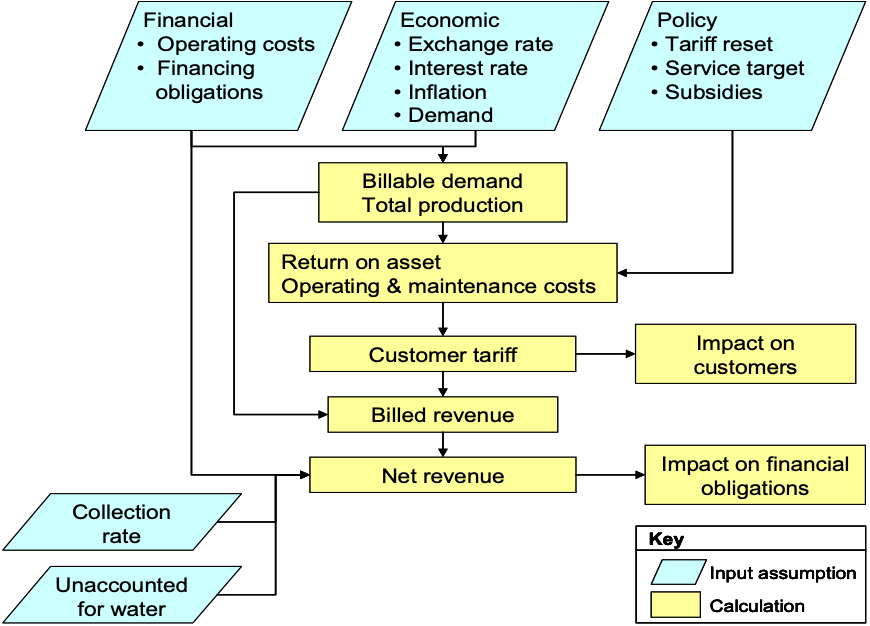

# 3 PARAMETERS

| VARIABLE | VALUES |
| --- | --- |
| CONTRACT_LENGTH_VAL | 20 |
| INFLATION_CURRENT_VAL | 0.05 |
| INFLATION_SPEED_ADJUSTMENT_VAL | 5 |
| INFLATION_LONG_TERM_VAL | 0.08 |
| INFLATION_VOLATILITY_VAL | 0.02 |
| INFLATION_INTIAL_CPI_VAL | 100 |
| INFLATION_INTIAL_DEFLATION_FACTOR_VAL | 1 |
| EXCHANGE_RATE_CURRENT_VAL | 100 |
| EXCHANGE_RATE_DEPRECIATION_VAL | 0.05 |
| EXCHANGE_RATE_VOLATILITY_VAL | 0.05 |

[output cut: 44 more lines]

# 4 FORMULATIONS

## 4.1 DETERMINISTIC

| PERIODS | I) ECONOMIC FACTORS: INFLATION | I) ECONOMIC FACTORS: CONSUMER PRICE INDEX | I) ECONOMIC FACTORS: DEFLATION FACTOR | I) ECONOMIC FACTORS: REAL EXCHANGE RATE | I) ECONOMIC FACTORS: NOMINAL EXCHANGE RATE | I) ECONOMIC FACTORS: DISCOUNT FACTOR | II) CONSUMPTION: POTENTIAL CONNECTIONS | II) CONSUMPTION: COVERAGE | II) CONSUMPTION: CONNECTIONS | II) CONSUMPTION: NEW CONNECTIONS | II) CONSUMPTION: DEMAND (L/CONNECTION/DAY) | II) CONSUMPTION: TOTAL DEMAND (M3) | II) CONSUMPTION: NON-REVENUE WATER | II) CONSUMPTION: COLLECTION RATE FORECAST | III) COSTS & SUBSIDIES: OPERATING FIXED COSTS - DOMESTIC DENOMINATION | III) COSTS & SUBSIDIES: OPERATING FIXED COSTS - FOREIGN DENOMINATION | III) COSTS & SUBSIDIES: OPERATING VARIABLE COSTS - DOMESTIC DENOMINATION | III) COSTS & SUBSIDIES: OPERATING VARIABLE COSTS - FOREIGN DENOMINATION | IV) FINANCING COSTS: COVERAGE EXTENSION COSTS | IV) FINANCING COSTS: AMOUNT FINANCED BY DEBT | IV) FINANCING COSTS: TOTAL LOAN REPAYMENT (FOREIGN CURRENCY) | IV) FINANCING COSTS: OUTSTANDING PRINCIPAL | IV) FINANCING COSTS: PRINCIPAL REPAYMENT | IV) FINANCING COSTS: INTEREST PAYMENT | IV) FINANCING COSTS: OPERATOR - OUTSTANDING PRINCIPAL | IV) FINANCING COSTS: OPERATOR - PRINCIPAL REPAYMENT | IV) FINANCING COSTS: OPERATOR - INTEREST PAYMENT | IV) FINANCING COSTS: CONTRACTING AUTHORITY - OUTSTANDING PRINCIPAL | IV) FINANCING COSTS: CONTRACTING AUTHORITY - PRINCIPAL REPAYMENT | … |
| --- | --- | --- | --- | --- | --- | --- | --- | --- | --- | --- | --- | --- | --- | --- | --- | --- | --- | --- | --- | --- | --- | --- | --- | --- | --- | --- | --- | --- | --- | --- |
| 0 | 0.05 | 100 | 1 | 100 | 105 | 1 | 50000 | 0.5 | 25000 | 0 | 150 | 1.36875 | 0.01 | 1 | 10 | 0.1 | 10 | 0.1 |  |  | 0.282580483 | 0 | 0 |  |  |  |  |  |  | … |
| 1 | 0.058091712 | 105.9812189 | 0.943563407 | 105.1271096 | 111.2341234 | 0.93239382 | 50000 | 0.505493471 | 25274 | 274 | 153.030201 | 1.411705135 | 0.010359724 | 1 | 10.30454534 | 0.103045453 | 10.30454534 | 0.103045453 | 0.58077708 | 0.29038854 | 0.000138113 | 0.002762261 | 0.000138113 | 0.000138113 | 0 | 0 | 0 | 0 | 0 | … |
| 2 | 0.064816775 | 113.0780935 | 0.884344588 | 110.5170918 | 117.6804533 | 0.869358235 | 50000 | 0.514656115 | 25732 | 458 | 156.1216161 | 1.466322321 | 0.012384058 | 1 | 10.61836547 | 0.106183655 | 10.61836547 | 0.106183655 | 1.035795337 | 0.517897668 | 0.00037242 | 0.00731028 | 0.00037242 | 0.000365514 | 0 | 0 | 0 | 0 | 0 | … |
| 3 | 0.069929009 | 121.2685711 | 0.824615967 | 116.1834243 | 124.308016 | 0.810584246 | 50000 | 0.53792909 | 26896 | 1164 | 159.275482 | 1.563613778 | 0.02 | 1 | 10.94174284 | 0.109417428 | 10.94174284 | 0.109417428 | 2.823132336 | 1.411566168 | 0.000979893 | 0.019087323 | 0.000979893 | 0.000954366 | 0 | 0 | 0 | 0 | 0 | … |
| 4 | 0.073540445 | 130.5228265 | 0.766149513 | 122.1402758 | 131.122526 | 0.755783741 | 50000 | 0.591212762 | 29560 | 2664 | 162.4930602 | 1.753202623 | 0.027615942 | 1 | 11.27496852 | 0.112749685 | 11.27496852 | 0.112749685 | 6.954256195 | 3.477128097 | 0.002403309 | 0.046575747 | 0.002403309 | 0.002328787 | 0 | 0 | 0 | 0 | 0 | … |
| 5 | 0.075954411 | 140.8228247 | 0.710112159 | 128.4025417 | 138.155281 | 0.70468809 | 50000 | 0.688770334 | 34438 | 4878 | 165.7756377 | 2.083778215 | 0.03 | 1 | 11.61834243 | 0.116183424 | 11.61834243 | 0.116183424 | 13.73867477 | 6.869337387 | 0.005078231 | 0.097670892 | 0.005078231 | 0.004883545 | 0 | 0 | 0 | 0 | 0 | … |
| 6 | 0.077506457 | 152.1716248 | 0.657152739 | 134.9858808 | 145.4481581 | 0.65704682 | 50000 | 0.811229666 | 40561 | 6123 | 169.1245277 | 2.503848889 | 0.03 | 1 | 11.97217363 | 0.119721736 | 11.97217363 | 0.119721736 | 18.63493717 | 9.317468587 | 0.008529507 | 0.161618166 | 0.008529507 | 0.008080908 | 0.186433133 | 0.009321657 | 0.009321657 | 0.186433133 | 0.009321657 | … |
| 7 | 0.078478834 | 164.5949865 | 0.60755192 | 141.9067549 | 153.0434316 | 0.612626394 | 50000 | 0.908787238 | 45439 | 4878 | 172.5410698 | 2.86163419 | 0.03 | 1 | 12.3367806 | 0.123367806 | 12.3367806 | 0.123367806 | 16.05788688 | 8.02894344 | 0.011358457 | 0.209667667 | 0.011358457 | 0.010483383 | 0.518689061 | 0.026424432 | 0.025934453 | 0.518689061 | 0.026424432 | … |
| 8 | 0.079078007 | 178.1393012 | 0.561358439 | 149.1824698 | 160.9795221 | 0.571209064 | 50000 | 0.96207091 | 48103 | 2664 | 176.0266306 | 3.09060429 | 0.03 | 1 | 12.7124915 | 0.127124915 | 12.7124915 | 0.127124915 | 9.491261971 | 4.745630985 | 0.012949003 | 0.230120126 | 0.012949003 | 0.011506006 | 1.423746994 | 0.073091413 | 0.07118735 | 1.423746994 | 0.073091413 | … |
| 9 | 0.079443395 | 192.8686198 | 0.518487663 | 156.8312185 | 169.290423 | 0.532591801 | 50000 | 0.985343885 | 49267 | 1164 | 179.5826045 | 3.229336104 | 0.03 | 1 | 13.09964451 | 0.130996445 | 13.09964451 | 0.130996445 | 4.489981469 | 2.244990735 | 0.013664737 | 0.231485816 | 0.013664737 | 0.011574291 | 3.6522656 | 0.188456911 | 0.18261328 | 3.6522656 | 0.188456911 | … |

[output cut: 11 more lines]

## 4.2 STOCHASTIC

| PERIODS | I) ECONOMIC FACTORS: INFLATION | I) ECONOMIC FACTORS: CONSUMER PRICE INDEX | I) ECONOMIC FACTORS: DEFLATION FACTOR | I) ECONOMIC FACTORS: REAL EXCHANGE RATE | I) ECONOMIC FACTORS: NOMINAL EXCHANGE RATE | I) ECONOMIC FACTORS: DISCOUNT FACTOR | II) CONSUMPTION: POTENTIAL CONNECTIONS | II) CONSUMPTION: COVERAGE | II) CONSUMPTION: CONNECTIONS | II) CONSUMPTION: NEW CONNECTIONS | II) CONSUMPTION: DEMAND (L/CONNECTION/DAY) | II) CONSUMPTION: TOTAL DEMAND (M3) | II) CONSUMPTION: NON-REVENUE WATER | II) CONSUMPTION: COLLECTION RATE FORECAST | III) COSTS & SUBSIDIES: OPERATING FIXED COSTS - DOMESTIC DENOMINATION | III) COSTS & SUBSIDIES: OPERATING FIXED COSTS - FOREIGN DENOMINATION | III) COSTS & SUBSIDIES: OPERATING VARIABLE COSTS - DOMESTIC DENOMINATION | III) COSTS & SUBSIDIES: OPERATING VARIABLE COSTS - FOREIGN DENOMINATION | IV) FINANCING COSTS: COVERAGE EXTENSION COSTS | IV) FINANCING COSTS: AMOUNT FINANCED BY DEBT | IV) FINANCING COSTS: TOTAL LOAN REPAYMENT (FOREIGN CURRENCY) | IV) FINANCING COSTS: OUTSTANDING PRINCIPAL | IV) FINANCING COSTS: PRINCIPAL REPAYMENT | IV) FINANCING COSTS: INTEREST PAYMENT | IV) FINANCING COSTS: OPERATOR - OUTSTANDING PRINCIPAL | IV) FINANCING COSTS: OPERATOR - PRINCIPAL REPAYMENT | IV) FINANCING COSTS: OPERATOR - INTEREST PAYMENT | IV) FINANCING COSTS: CONTRACTING AUTHORITY - OUTSTANDING PRINCIPAL | IV) FINANCING COSTS: CONTRACTING AUTHORITY - PRINCIPAL REPAYMENT | … |
| --- | --- | --- | --- | --- | --- | --- | --- | --- | --- | --- | --- | --- | --- | --- | --- | --- | --- | --- | --- | --- | --- | --- | --- | --- | --- | --- | --- | --- | --- | --- |
| 0 | 0.05 | 100 | 1 | 100 | 105 | 1 | 50000 | 0.5 | 25000 | 0 | 150 | 1.36875 | 0.01 | 1 | 10 | 0.1 | 10 | 0.1 |  |  | 0.262223038 | 0 | 0 |  |  |  |  |  |  | … |
| 1 | 0.057289346 | 105.8962173 | 0.944320794 | 104.5769704 | 110.5681167 | 0.93239382 | 50000 | 0.505493471 | 25274 | 274 | 150.0983661 | 1.384658928 | 0.010359724 | 1 | 10.30454534 | 0.103045453 | 10.30454534 | 0.103045453 | 0.580311271 | 0.290155635 | 0.000138728 | 0.002774565 | 0.000138728 | 0.000138728 | 0 | 0 | 0 | 0 | 0 | … |
| 2 | 0.06525551 | 113.0369823 | 0.884666221 | 119.1265107 | 126.9001719 | 0.869358235 | 50000 | 0.514656115 | 25732 | 458 | 151.0186813 | 1.418394638 | 0.012384058 | 1 | 10.61836547 | 0.106183655 | 10.61836547 | 0.106183655 | 1.035418758 | 0.517709379 | 0.000356022 | 0.006981716 | 0.000356022 | 0.000349086 | 0 | 0 | 0 | 0 | 0 | … |
| 3 | 0.073456471 | 121.652852 | 0.822011144 | 126.77079 | 136.0829248 | 0.810584246 | 50000 | 0.53792909 | 26896 | 1164 | 153.8292247 | 1.510147652 | 0.02 | 1 | 10.94174284 | 0.109417428 | 10.94174284 | 0.109417428 | 2.832078394 | 1.416039197 | 0.000914526 | 0.017795768 | 0.000914526 | 0.000889788 | 0 | 0 | 0 | 0 | 0 | … |
| 4 | 0.073936523 | 130.9883039 | 0.76342694 | 132.5609063 | 142.3619988 | 0.755783741 | 50000 | 0.591212762 | 29560 | 2664 | 158.1971342 | 1.70685216 | 0.027615942 | 1 | 11.27496852 | 0.112749685 | 11.27496852 | 0.112749685 | 6.979056833 | 3.489528416 | 0.002230724 | 0.043205206 | 0.002230724 | 0.00216026 | 0 | 0 | 0 | 0 | 0 | … |
| 5 | 0.075590685 | 141.2736403 | 0.707846133 | 144.1450621 | 155.041086 | 0.70468809 | 50000 | 0.688770334 | 34438 | 4878 | 165.1170523 | 2.075499882 | 0.03 | 1 | 11.61834243 | 0.116183424 | 11.61834243 | 0.116183424 | 13.78265634 | 6.891328172 | 0.004621138 | 0.088782766 | 0.004621138 | 0.004439138 | 0 | 0 | 0 | 0 | 0 | … |
| 6 | 0.076503068 | 152.505672 | 0.655713317 | 146.3729697 | 157.570951 | 0.65704682 | 50000 | 0.811229666 | 40561 | 6123 | 164.5643518 | 2.436336555 | 0.03 | 1 | 11.97217363 | 0.119721736 | 11.97217363 | 0.119721736 | 18.6758446 | 9.337922299 | 0.007810908 | 0.147957029 | 0.007810908 | 0.007397851 | 0.203060683 | 0.010153034 | 0.010153034 | 0.203060683 | 0.010153034 | … |
| 7 | 0.078387357 | 164.9412163 | 0.606276601 | 155.3616424 | 167.5400308 | 0.612626394 | 50000 | 0.908787238 | 45439 | 4878 | 164.5628521 | 2.729313574 | 0.03 | 1 | 12.3367806 | 0.123367806 | 12.3367806 | 0.123367806 | 16.09166506 | 8.045832531 | 0.010400297 | 0.191933888 | 0.010400297 | 0.009596694 | 0.542345422 | 0.027656097 | 0.027117271 | 0.542345422 | 0.027656097 | … |
| 8 | 0.079060956 | 178.5109781 | 0.560189637 | 155.4592203 | 167.7499748 | 0.571209064 | 50000 | 0.96207091 | 48103 | 2664 | 168.639306 | 2.960900636 | 0.03 | 1 | 12.7124915 | 0.127124915 | 12.7124915 | 0.127124915 | 9.511064912 | 4.755532456 | 0.011929808 | 0.212123815 | 0.011929808 | 0.010606191 | 1.383258139 | 0.071085745 | 0.069162907 | 1.383258139 | 0.071085745 | … |
| 9 | 0.083232332 | 194.0047092 | 0.515451405 | 157.4735608 | 170.5804524 | 0.532591801 | 50000 | 0.985343885 | 49267 | 1164 | 168.2756496 | 3.026009296 | 0.03 | 1 | 13.09964451 | 0.130996445 | 13.09964451 | 0.130996445 | 4.51642963 | 2.258214815 | 0.012646822 | 0.214534286 | 0.012646822 | 0.010726714 | 3.401838787 | 0.175640034 | 0.170091939 | 3.401838787 | 0.175640034 | … |

[output cut: 11 more lines]

# 5 RESULTS

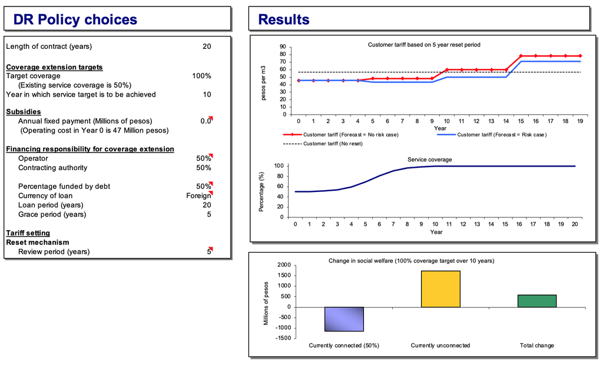

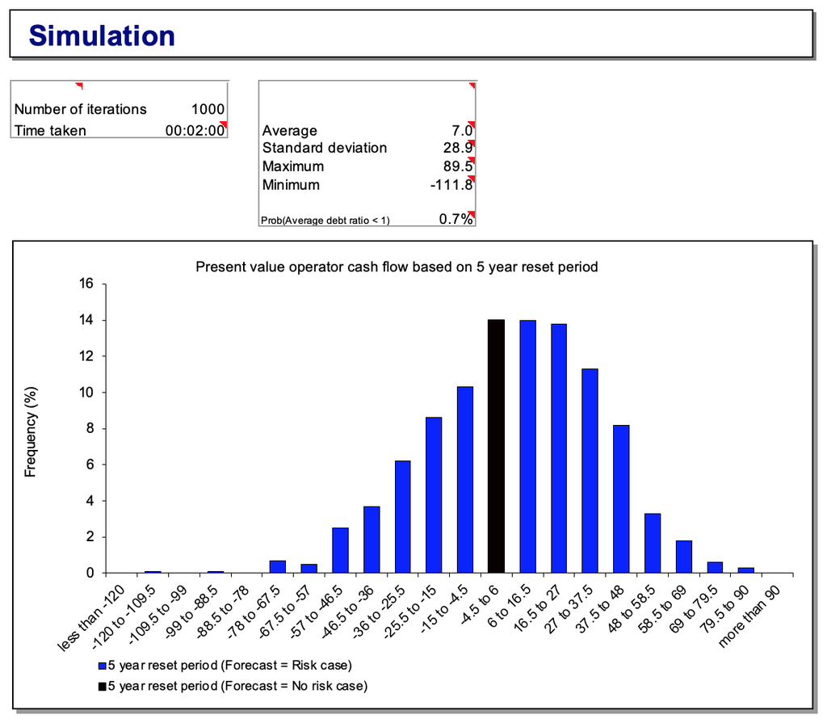

# 6 CODE

Written by [Carlos Arias Perez](https://www.linkedin.com/in/carlosarias-perez/) and [Rafael Nicolas Fermin Cota](https://www.linkedin.com/in/rnfc/).

Last Update 2022-09-14

```r
source("../libs/code.R") #
WATER_UTILITY_SAMPLING_FUNC
function (INPUTS, RISK_TOGGLE)
{
    for (j in 1:length(INPUTS)) assign(names(INPUTS)[j], INPUTS[[j]])
    HEADINGS_STR = "PERIODS,I) ECONOMIC FACTORS: INFLATION,I) ECONOMIC FACTORS: CONSUMER PRICE INDEX,I) ECONOMIC FACTORS: DEFLATION FACTOR,I) ECONOMIC FACTORS: REAL EXCHANGE RATE,I) ECONOMIC FACTORS: NOMINAL EXCHANGE RATE,I) ECONOMIC FACTORS: DISCOUNT FACTOR,"
    HEADINGS_STR = paste0(HEADINGS_STR, "II) CONSUMPTION: POTENTIAL CONNECTIONS,II) CONSUMPTION: COVERAGE,II) CONSUMPTION: CONNECTIONS,II) CONSUMPTION: NEW CONNECTIONS,II) CONSUMPTION: DEMAND (L/CONNECTION/DAY),II) CONSUMPTION: TOTAL DEMAND (M3),II) CONSUMPTION: NON-REVENUE WATER,II) CONSUMPTION: COLLECTION RATE FORECAST,")
    HEADINGS_STR = paste0(HEADINGS_STR, "III) COSTS & SUBSIDIES: OPERATING FIXED COSTS - DOMESTIC DENOMINATION,III) COSTS & SUBSIDIES: OPERATING FIXED COSTS - FOREIGN DENOMINATION,III) COSTS & SUBSIDIES: OPERATING VARIABLE COSTS - DOMESTIC DENOMINATION,III) COSTS & SUBSIDIES: OPERATING VARIABLE COSTS - FOREIGN DENOMINATION,")
    HEADINGS_STR = paste0(HEADINGS_STR, "IV) FINANCING COSTS: COVERAGE EXTENSION COSTS,IV) FINANCING COSTS: AMOUNT FINANCED BY DEBT,IV) FINANCING COSTS: TOTAL LOAN REPAYMENT (FOREIGN CURRENCY),IV) FINANCING COSTS: OUTSTANDING PRINCIPAL,IV) FINANCING COSTS: PRINCIPAL REPAYMENT,IV) FINANCING COSTS: INTEREST PAYMENT,IV) FINANCING COSTS: OPERATOR - OUTSTANDING PRINCIPAL,IV) FINANCING COSTS: OPERATOR - PRINCIPAL REPAYMENT,IV) FINANCING COSTS: OPERATOR - INTEREST PAYMENT,IV) FINANCING COSTS: CONTRACTING AUTHORITY - OUTSTANDING PRINCIPAL,IV) FINANCING COSTS: CONTRACTING AUTHORITY - PRINCIPAL REPAYMENT,IV) FINANCING COSTS: CONTRACTING AUTHORITY - INTEREST PAYMENT,")
    HEADINGS_STR = paste0(HEADINGS_STR, "V) TARIFF RESET CALCULATIONS: EXPECTED INFLATION RATE - FORECAST USED FOR TARIFF SETTING,V) TARIFF RESET CALCULATIONS: EXPECTED INFLATION RATE - DEFLATION FACTOR,V) TARIFF RESET CALCULATIONS: ASSET BASE (NOMINAL) - INITIAL EXISTING ASSET BASE,V) TARIFF RESET CALCULATIONS: EXISTING ASSET BASE (NOMINAL) - DEPRECIATION,V) TARIFF RESET CALCULATIONS: ASSET BASE (NOMINAL) - MAINTENANCE COSTS,V) TARIFF RESET CALCULATIONS: ASSET BASE (NOMINAL) - FINAL EXISTING ASSET BASE,V) TARIFF RESET CALCULATIONS: ASSET BASE (NOMINAL) - INITIAL NEW ASSET BASE,V) TARIFF RESET CALCULATIONS: ASSET BASE (NOMINAL) - INVESTMENT,V) TARIFF RESET CALCULATIONS: NEW ASSET BASE (NOMINAL) - DEPRECIATION,V) TARIFF RESET CALCULATIONS: ASSET BASE (NOMINAL) - FINAL NEW ASSET BASE,")
    HEADINGS_STR = paste0(HEADINGS_STR, "V) TARIFF RESET CALCULATIONS: DEMAND - NO RESET,V) TARIFF RESET CALCULATIONS: DEMAND - FULL RESET,V) TARIFF RESET CALCULATIONS: DEMAND - DISCOUNTED DEMAND,V) TARIFF RESET CALCULATIONS: DEMAND - CUMULATIVE DISCOUNTED DEMAND,V) TARIFF RESET CALCULATIONS: DEMAND - ",
        TARIFF_REVIEW_PERIOD_VAL, " YEAR DISCOUNTED DEMAND,V) TARIFF RESET CALCULATIONS: RETURN ON NEW ASSETS (REAL) - CONTRACTING AUTHORITY,V) TARIFF RESET CALCULATIONS: RETURN ON NEW ASSETS (REAL) - OPERATOR,V) TARIFF RESET CALCULATIONS: DEPRECIATION (REAL) - CONTRACTING AUTHORITY,V) TARIFF RESET CALCULATIONS: DEPRECIATION (REAL) - OPERATOR,V) TARIFF RESET CALCULATIONS: MAINTENANCE COSTS (REAL),")
    HEADINGS_STR = paste0(HEADINGS_STR, "V) TARIFF RESET CALCULATIONS: DOMESTIC-DENOMINATED OPEX (REAL),V) TARIFF RESET CALCULATIONS: FOREIGN-DENOMINATED OPEX (REAL),V) TARIFF RESET CALCULATIONS: FOREIGN EXCHANGE RATE - NO RESET,V) TARIFF RESET CALCULATIONS: FOREIGN EXCHANGE RATE - FULL RESET,V) TARIFF RESET CALCULATIONS: SUBSIDIES (REAL),V) TARIFF RESET CALCULATIONS: REVENUE REQUIREMENT (REAL) - CONTRACTING AUTHORITY - REVENUE REQUIREMENT,V) TARIFF RESET CALCULATIONS: REVENUE REQUIREMENT (REAL) - CONTRACTING AUTHORITY - DISCOUNTED REVENUE REQUIREMENT,V) TARIFF RESET CALCULATIONS: REVENUE REQUIREMENT (REAL) - CONTRACTING AUTHORITY - CUMULATIVE DISCOUNTED REVENUE REQUIREMENT,V) TARIFF RESET CALCULATIONS: REVENUE REQUIREMENT (REAL) - OPERATOR - REVENUE REQUIREMENT,V) TARIFF RESET CALCULATIONS: REVENUE REQUIREMENT (REAL) - OPERATOR - DISCOUNTED REVENUE REQUIREMENT,")
    HEADINGS_STR = paste0(HEADINGS_STR, "V) TARIFF RESET CALCULATIONS: REVENUE REQUIREMENT (REAL) - OPERATOR - CUMULATIVE DISCOUNTED REVENUE REQUIREMENT,V) TARIFF RESET CALCULATIONS: DISCOUNTED REVENUE REQUIREMENT - CONTRACTING AUTHORITY,V) TARIFF RESET CALCULATIONS: DISCOUNTED REVENUE REQUIREMENT - OPERATOR,V) TARIFF RESET CALCULATIONS: REVENUE REQUIRED PER M3 - NO RESET - CONTRACTING AUTHORITY,V) TARIFF RESET CALCULATIONS: REVENUE REQUIRED PER M3 - NO RESET - OPERATOR,V) TARIFF RESET CALCULATIONS: REVENUE REQUIRED PER M3 - ",
        TARIFF_REVIEW_PERIOD_VAL, " YEAR RESET PERIOD - CONTRACTING AUTHORITY,V) TARIFF RESET CALCULATIONS: REVENUE REQUIRED PER M3 - ",
        TARIFF_REVIEW_PERIOD_VAL, " YEAR RESET PERIOD - OPERATOR,")
    HEADINGS_STR = paste0(HEADINGS_STR, "VI) TARIFF INDEXATION: INDEXATION,VI) TARIFF INDEXATION: NO RESET - CONTRACTING AUTHORITY,VI) TARIFF INDEXATION: NO RESET - OPERATOR,VI) TARIFF INDEXATION: ",
        TARIFF_REVIEW_PERIOD_VAL, " YEAR RESET PERIOD - CONTRACTING AUTHORITY,VI) TARIFF INDEXATION: ",
        TARIFF_REVIEW_PERIOD_VAL, " YEAR RESET PERIOD - OPERATOR,")
    HEADINGS_STR = paste0(HEADINGS_STR, "VII) PROFIT: TOTAL REVENUE COLLECTED - NO RESET,VII) PROFIT: TOTAL REVENUE COLLECTED - ",
        TARIFF_REVIEW_PERIOD_VAL, " YEAR RESET PERIOD,VII) PROFIT: COSTS - OPERATING COSTS,VII) PROFIT: COSTS - MAINTENANCE COSTS,VII) PROFIT: COSTS - RETURN ON CAPITAL,VII) PROFIT: COSTS - DEPRECIATION,VII) PROFIT: COSTS - SUBSIDIES,VII) PROFIT: COSTS - TOTAL,VII) PROFIT: PRESENT VALUE PROFIT (REAL) - NO RESET,VII) PROFIT: PRESENT VALUE PROFIT (REAL) - ",
        TARIFF_REVIEW_PERIOD_VAL, " YEAR RESET PERIOD,")
    HEADINGS_STR = paste0(HEADINGS_STR, "VIII) CASH FLOWS: NO RESET - CONTRACTING AUTHORITY,VIII) CASH FLOWS: NO RESET - OPERATOR,VIII) CASH FLOWS: ",
        TARIFF_REVIEW_PERIOD_VAL, " YEAR RESET PERIOD - CONTRACTING AUTHORITY,VIII) CASH FLOWS: ",
        TARIFF_REVIEW_PERIOD_VAL, " YEAR RESET PERIOD - OPERATOR,")
    HEADINGS_STR = paste0(HEADINGS_STR, "IX) DEBT SERVICE RATIO: CASH FLOW BEFORE LOAN REPAYMENT - NO RESET,IX) DEBT SERVICE RATIO: CASH FLOW BEFORE LOAN REPAYMENT - ",
        TARIFF_REVIEW_PERIOD_VAL, " YEAR RESET PERIOD,IX) DEBT SERVICE RATIO: DEBT SERVICE RATIO - NO RESET,IX) DEBT SERVICE RATIO: DEBT SERVICE RATIO - ",
        TARIFF_REVIEW_PERIOD_VAL, " YEAR RESET PERIOD,")
    HEADINGS_STR = paste0(HEADINGS_STR, "X) STAKEHOLDER ANALYSIS: WATER USE & CONSUMPTION - PRIVATE HOUSEHOLD CONNECTION,X) STAKEHOLDER ANALYSIS: WATER USE & CONSUMPTION - OTHER SOURCES,X) STAKEHOLDER ANALYSIS: MONTHLY COST - PRIVATE HOUSEHOLD CONNECTION - ",
        TARIFF_REVIEW_PERIOD_VAL, " YEAR RESET PERIOD,X) STAKEHOLDER ANALYSIS: MONTHLY COST - PRIVATE HOUSEHOLD CONNECTION - EXISTING TARIFFS,X) STAKEHOLDER ANALYSIS: OTHER SOURCES,X) STAKEHOLDER ANALYSIS: MONTHLY COPING COST - OTHER SOURCES,X) STAKEHOLDER ANALYSIS: WILLINGNESS TO PAY - PRIVATE HOUSEHOLD CONNECTION,X) STAKEHOLDER ANALYSIS: WILLINGNESS TO PAY - OTHER SOURCES - MONTHLY COST,X) STAKEHOLDER ANALYSIS: WILLINGNESS TO PAY - OTHER SOURCES - MONTHLY COPING COST,X) STAKEHOLDER ANALYSIS: CHANGE IN SOCIAL WELFARE (REAL) - PRIVATE HOUSEHOLD CONNECTION,X) STAKEHOLDER ANALYSIS: CHANGE IN SOCIAL WELFARE (REAL) - OTHER SOURCES,")
    nm = strsplit(HEADINGS_STR, ",")[[1]]
    nrows = CONTRACT_LENGTH_VAL + 1
    ncols = length(nm)
    mat = data.frame(matrix(0, nrows, ncols))
    names(mat) = nm
    mat[, 20:68] = 0
    mat[1, 1] = 0
    mat[1, 2] = INFLATION_CURRENT_VAL
    mat[1, 3] = INFLATION_INTIAL_CPI_VAL
    mat[1, 4] = INFLATION_INTIAL_DEFLATION_FACTOR_VAL
    mat[1, 5] = EXCHANGE_RATE_CURRENT_VAL
    mat[1, 6] = mat[1, 5] * (1 + mat[1, 2])
    mat[1, 7] = DISCOUNT_INITIAL_FACTOR_VAL
    mat[1, 8] = CUSTOMERS_CURRENT_VAL
    mat[1, 9] = SERVICE_COVERAGE_CURRENT_VAL
    mat[1, 10] = as.integer(mat[1, 8] * mat[1, 9])
    mat[1, 11] = 0
    mat[1, 12] = DEMAND_CURRENT_VAL
    mat[1, 92] = mat[1, 12]
    mat[1, 93] = DEMAND_OTHER_SOURCES_VAL
    mat[1, 13] = mat[1, 12] * mat[1, 10] * 365/1000/DENOMINATIONS_WATER_VOLUMES_VAL
    mat[1, 14] = NON_REVENUE_WATER_CURRENT_VAL
    mat[1, 15] = COLLECTION_RATE_CURRENT_VAL
    TEMP_VAL = FIXED_OPERATING_COSTS_EXISTING_PERCENT_INVESTMENT_COST_PER_CONNECTION_VAL *
        INVESTMENT_COST_PER_NEW_CONNECTION_LOCAL_CURRENCY_VAL *
        SERVICE_COVERAGE_CURRENT_VAL * CUSTOMERS_CURRENT_VAL
    mat[1, 16] = (TEMP_VAL/DENOMINATIONS_MONETARY_VAL) * (1 -
        FIXED_OPERATING_COSTS_PROPORTION_OF_COSTS_DENOMINATED_IN_FOREIGN_CURRENCY_VAL)
    mat[1, 17] = (TEMP_VAL/DENOMINATIONS_MONETARY_VAL) * FIXED_OPERATING_COSTS_PROPORTION_OF_COSTS_DENOMINATED_IN_FOREIGN_CURRENCY_VAL/EXCHANGE_RATE_CURRENT_VAL
    mat[1, 18] = VARIABLE_OPERATING_COSTS_EXISTING_COST_VAL *
        (1 - VARIABLE_OPERATING_COSTS_PROPORTION_OF_COSTS_DENOMINATED_IN_FOREIGN_CURRENCY_VAL)
    mat[1, 19] = VARIABLE_OPERATING_COSTS_EXISTING_COST_VAL *
        VARIABLE_OPERATING_COSTS_PROPORTION_OF_COSTS_DENOMINATED_IN_FOREIGN_CURRENCY_VAL/EXCHANGE_RATE_CURRENT_VAL
    i = 2:nrows
    j = i - 1
    k = i[-1]
    mat[i, 1] = j
    TFLAG1_VAL = ((TARIFF_REVIEW_PERIOD_VAL == 1) | (j%%TARIFF_REVIEW_PERIOD_VAL ==
        1))
    TFLAG2_VAL = (j%%TARIFF_REVIEW_PERIOD_VAL == 1)
    if (!RISK_TOGGLE) {
        mat[i, 2] = Reduce(function(prv, nxt) prv * exp(INFLATION_SPEED_ADJUSTMENT_VAL *
            (INFLATION_LONG_TERM_VAL - prv)), rep(1, nrows -
            1), mat[1, 2], accumulate = TRUE)[-1]
        mat[i, 5] = cumprod(c(mat[1, 5], rep(exp(EXCHANGE_RATE_DEPRECIATION_VAL),
            nrows - 1)))[-1]
        mat[i, 12] = cumprod(c(mat[1, 12], rep(exp(DEMAND_ANNUAL_GROWTH_VAL),
            nrows - 1)))[-1]
        mat[i, 92] = mat[i, 12]
        mat[i, 93] = cumprod(c(mat[1, 93], rep(exp(DEMAND_ANNUAL_GROWTH_VAL),
            nrows - 1)))[-1]
    }
    else {
        rnd1 = c(-1.63530374963851, -0.68541620176237, 0.842126679004853,
            2.24300314945776, -1.30018563892108, -0.399562916625586,
            -0.492439250657473, 0.352356975065116, 0.0346640557438982,
            2.34607539004499, -0.139182297384679, -1.36517849320719,
            2.55653827914048, 0.915935927357113, 0.285107591845216,
            -0.40912433095963, 0.419106733017931, -1.00891713566328,
            0.565359609265667, 0.166988419109934, 1.92580344598388)
        rnd2 = c(1.75556803913375, -0.0799365289157126, 1.63025368036105,
            0.268892180257083, -0.0817688484778561, 0.700559159611574,
            -0.668244340991706, 0.216952495929201, -0.962442548216423,
            -0.717517445102393, 0.0986384764455445, -0.667207935530494,
            -0.619421357051072, -0.991318012291069, 0.634356804887895,
            1.06147409139581, 0.495289926518602, -0.76369614118954,
            0.504454895729237, 0.120628984655496, -1.13045729301784)
        rnd3 = c(-1.04221645740392, -0.629814708524595, -0.447910219752754,
            -0.0370163283177808, 0.281629466353362, 0.775422988816911,
            -0.763431339408918, -0.651970442137781, 0.163985782433124,
            -0.723624801741545, 1.26790409376486, 0.0320993689595026,
            0.418757422595019, -0.539957290211319, 0.41082096870385,
            -2.15717521594011, -0.880684029801793, 0.425257055847261,
            0.112015247259036, -0.581296892902507, 0.724839944832975)
        rnd4 = c(-1.04221645740392, -0.629814708524595, -0.447910219752754,
            -0.0370163283177808, 0.281629466353362, 0.775422988816911,
            -0.763431339408918, -0.651970442137781, 0.163985782433124,
            -0.723624801741545, 1.26790409376486, 0.0320993689595026,
            0.418757422595019, -0.539957290211319, 0.41082096870385,
            -2.15717521594011, -0.880684029801793, 0.425257055847261,
            0.112015247259036, -0.581296892902507, 0.724839944832975)
        mat[i, 2] = Reduce(function(prv, nxt) {
            EXPECTED_CHANGE_VAL = INFLATION_SPEED_ADJUSTMENT_VAL *
```

```r
                (INFLATION_LONG_TERM_VAL - prv)
            prv * exp(EXPECTED_CHANGE_VAL - INFLATION_VOLATILITY_VAL *
                INFLATION_VOLATILITY_VAL/2 + INFLATION_VOLATILITY_VAL *
                nxt)
        }, rnd1[-1], mat[1, 2], accumulate = TRUE)[-1]
        mat[i, 5] = Reduce(function(prv, nxt) {
            prv * exp(EXCHANGE_RATE_DEPRECIATION_VAL - EXCHANGE_RATE_VOLATILITY_VAL *
                EXCHANGE_RATE_VOLATILITY_VAL/2 + EXCHANGE_RATE_VOLATILITY_VAL *
                nxt)
        }, rnd2[-1], mat[1, 5], accumulate = TRUE)[-1]
        mat[i, 12] = Reduce(function(prv, nxt) {
            prv * exp(DEMAND_ANNUAL_GROWTH_VAL - DEMAND_VOLATILITY_VAL *
                DEMAND_VOLATILITY_VAL/2 + DEMAND_VOLATILITY_VAL *
                nxt)
        }, rnd3[-1], mat[1, 12], accumulate = TRUE)[-1]
        mat[i, 92] = mat[i, 12]
        mat[i, 93] = Reduce(function(prv, nxt) {
            prv * exp(DEMAND_ANNUAL_GROWTH_VAL - DEMAND_VOLATILITY_VAL *
                DEMAND_VOLATILITY_VAL/2 + DEMAND_VOLATILITY_VAL *
                nxt)
        }, rnd4[-1], mat[1, 93], accumulate = TRUE)[-1]
    }
    mat[i, 3] = Reduce(function(prv, nxt) {
        prv * exp(nxt)
    }, mat[i, 2], mat[1, 3], accumulate = TRUE)[-1]
    mat[i, 4] = Reduce(function(prv, nxt) {
        prv * exp(-nxt)
    }, mat[i, 2], mat[1, 3], accumulate = TRUE)[-1]/100
    mat[i, 6] = mat[i, 5] * (1 + mat[i, 2])
    mat[i, 7] = cumprod(c(mat[1, 7], rep(exp(-DISCOUNT_RATE_VAL),
        nrows - 1)))[-1]
    mat[i, 8] = cumprod(c(mat[1, 8], rep(exp(CUSTOMERS_ANNUAL_GROWTH_VAL),
        nrows - 1)))[-1]
    mat[i, 9] = ifelse(mat[i, 1] < SERVICE_COVERAGE_YEAR_VAL,
        SERVICE_COVERAGE_CURRENT_VAL + (SERVICE_COVERAGE_TARGET_VAL -
            SERVICE_COVERAGE_CURRENT_VAL)/(1 + exp(-(10/SERVICE_COVERAGE_YEAR_VAL) *
            (mat[i, 1] - 1 - (SERVICE_COVERAGE_YEAR_VAL - 1)/2))),
        SERVICE_COVERAGE_TARGET_VAL)
    mat[i, 10] = as.integer(mat[i, 8] * mat[i, 9])
    mat[i, 11] = ifelse(diff(mat[, 10]) > 0, diff(mat[, 10]),
        0)
    mat[i, 13] = mat[i, 12] * mat[i, 10] * 365/1000/DENOMINATIONS_WATER_VOLUMES_VAL
    mat[i, 14] = ifelse(mat[i, 1] < NON_REVENUE_WATER_YEAR_VAL,
        NON_REVENUE_WATER_CURRENT_VAL + (NON_REVENUE_WATER_TARGET_VAL -
            NON_REVENUE_WATER_CURRENT_VAL)/(1 + exp(-(10/NON_REVENUE_WATER_YEAR_VAL) *
            (mat[i, 1] - 1 - (NON_REVENUE_WATER_YEAR_VAL - 1)/2))),
        NON_REVENUE_WATER_TARGET_VAL)
    mat[i, 15] = ifelse(mat[i, 1] < COLLECTION_RATE_YEAR_VAL,
        COLLECTION_RATE_CURRENT_VAL + (COLLECTION_RATE_TARGET_VAL -
            COLLECTION_RATE_CURRENT_VAL)/(1 + exp(-(10/COLLECTION_RATE_YEAR_VAL) *
            (mat[i, 1] - 1 - (COLLECTION_RATE_YEAR_VAL - 1)/2))),
        COLLECTION_RATE_TARGET_VAL)
    mat[i, 16] = cumprod(c(mat[1, 16], rep(exp(FIXED_OPERATING_COSTS_ANNUAL_REAL_GROWTH_RATE_VAL),
        nrows - 1)))[-1]
    mat[i, 17] = cumprod(c(mat[1, 17], rep(exp(FIXED_OPERATING_COSTS_ANNUAL_REAL_GROWTH_RATE_VAL),
        nrows - 1)))[-1]
    mat[i, 18] = cumprod(c(mat[1, 18], rep(exp(VARIABLE_OPERATING_COSTS_ANNUAL_REAL_GROWTH_RATE_VAL),
        nrows - 1)))[-1]
    mat[i, 19] = cumprod(c(mat[1, 19], rep(exp(VARIABLE_OPERATING_COSTS_ANNUAL_REAL_GROWTH_RATE_VAL),
        nrows - 1)))[-1]
    mat[i, 20] = mat[i, 11] * INVESTMENT_COST_PER_NEW_CONNECTION_LOCAL_CURRENCY_VAL/(mat[i,
        4] * DENOMINATIONS_MONETARY_VAL)
    mat[i, 21] = PERCENTAGE_FUNDED_BY_DEBT_VAL * mat[i, 20]
    if (LOAN_FOREIGN_CURRENCY_VAL == 1) {
        d1 = mat[2, 5]
        dn = mat[i, 5]
    }
    else {
        d1 = 1
        dn = d1
    }
    mat[1, 22] = sum(mat[i, 21]/dn)
    mat[i, 22] = cumsum((mat[i, 21]/dn)/LOAN_PERIOD_VAL)
    mat[i, 23] = Reduce(function(prv, nxt) {
        prv + nxt
    }, -(mat[i, 22])[-nrows + 2] + (mat[i, 21]/dn)[-1], mat[2,
        21]/d1, accumulate = TRUE)
    mat[i, 24] = mat[i, 22]
    mat[i, 25] = mat[i, 23] * INTEREST_RATE_VAL
    j = i - 1
    l = which(j <= LOAN_PERIOD_GRACE_VAL)
    l = c(l, LOAN_PERIOD_GRACE_VAL + 1)
    mat[l, 26:31] = 0
    l = which(j > LOAN_PERIOD_GRACE_VAL)
    l = l + 1
    TEMP_ARR = dn[l - 1]
    mat[l, 26:28] = mat[l - LOAN_PERIOD_GRACE_VAL, 26:28 - 3] *
        TEMP_ARR * FINANCING_RESPONSIBILITY_COVERAGE_EXTENSION_OPERATOR_VAL
    mat[l, 29:31] = mat[l - LOAN_PERIOD_GRACE_VAL, 29:31 - 6] *
        TEMP_ARR * FINANCING_RESPONSIBILITY_COVERAGE_EXTENSION_CONTRACTING_AUTHORITY_VAL
    if (!RISK_TOGGLE) {
        mat[, 32] = NA_real_
        mat[, 33] = NA_real_
        mat[1, 37] = ASSET_BASE_INITIAL_LOCAL_CURRENCY_VAL/DENOMINATIONS_MONETARY_VAL
        mat[i, 37] = Reduce(function(prv, nxt) {
            prv * exp(nxt)
        }, mat[i, 2], mat[1, 37], accumulate = TRUE)[-1]
        mat[i, 34] = mat[i - 1, 37]
        mat[i, 35] = mat[i - 1, 37] * ASSET_BASE_DEPRECIATION_RATE_VAL
        mat[i, 39] = mat[i, 20]
        mat[, 42] = NA_real_
        mat[, 43] = NA_real_
        mat[i, 44] = mat[i, 13] * mat[i, 7]
        mat[i, 52] = (mat[i, 16] + mat[i, 18] * mat[i, 13]/(1 -
            mat[i, 14]))
        mat[i, 53] = (mat[i, 17] + mat[i, 19] * mat[i, 13]/(1 -
            mat[i, 14])) * mat[i, 5]
        mat[, 54] = NA_real_
        mat[, 55] = NA_real_
        TEMP_ARR = mat[i, 4]
    }
    else {
        mat[1, 32] = mat[1, 2]
        mat[2, 32] = mat[1, 32] * exp(INFLATION_SPEED_ADJUSTMENT_VAL *
            (INFLATION_LONG_TERM_VAL - mat[1, 32]))
        mat[k, 32] = Reduce(function(prv, nxt) {
            if (TFLAG1_VAL[nxt - 1]) {
                mat[nxt, 2]
            }
            else {
                prv * exp(INFLATION_SPEED_ADJUSTMENT_VAL * (INFLATION_LONG_TERM_VAL -
                  prv))
            }
        }, k, mat[2, 32], accumulate = TRUE)[-1]
        mat[1, 37] = ASSET_BASE_INITIAL_LOCAL_CURRENCY_VAL/DENOMINATIONS_MONETARY_VAL
        mat[2, 37] = mat[1, 37] * exp(mat[2, 32])
        mat[k, 37] = Reduce(function(prv, nxt) {
            if (TFLAG2_VAL[nxt - 1]) {
                prv * exp(mat[nxt, 2])
            }
            else {
                prv * exp(mat[nxt, 32])
            }
        }, k, mat[2, 37], accumulate = TRUE)[-1]
        mat[1, 34] = 0
        mat[2, 34] = mat[1, 37]
        mat[k, 34] = mat[k - 1, 37]
        mat[1, 35] = 0 * ASSET_BASE_DEPRECIATION_RATE_VAL
        mat[2, 35] = mat[1, 37] * ASSET_BASE_DEPRECIATION_RATE_VAL
        mat[k, 35] = mat[k - 1, 37] * ASSET_BASE_DEPRECIATION_RATE_VAL
        DDEMAND_VAL = cumprod(c(mat[1, 12], rep(exp(DEMAND_ANNUAL_GROWTH_VAL),
            nrows - 1)))
        TDEMAND_VAL = DDEMAND_VAL * mat[, 10] * 365/1000/DENOMINATIONS_WATER_VOLUMES_VAL
        mat[1, 42] = 0
        mat[2, 42] = TDEMAND_VAL[2]
        mat[k, 42] = Reduce(function(prv, nxt) {
            if (TDEMAND_VAL[nxt] != 0) {
                prv/mat[nxt - 1, 10] * exp(DEMAND_ANNUAL_GROWTH_VAL) *
                  mat[nxt, 10]
            }
            else {
                prv
            }
        }, k, mat[2, 42], accumulate = TRUE)[-1]
        mat[1, 43] = mat[1, 42]
        mat[2, 43] = mat[2, 42]
        mat[k, 43] = Reduce(function(prv, nxt) {
            if (TFLAG2_VAL[nxt - 1]) {
                mat[nxt, 13]
            }
            else {
                prv/mat[nxt - 1, 10] * exp(DEMAND_ANNUAL_GROWTH_VAL) *
                  mat[nxt, 10]
            }
        }, k, mat[2, 43], accumulate = TRUE)[-1]
        mat[1, 54] = 0
        mat[2, 54] = EXCHANGE_RATE_CURRENT_VAL * exp(EXCHANGE_RATE_DEPRECIATION_VAL)
        mat[k, 54] = cumprod(c(mat[2, 54], rep(exp(EXCHANGE_RATE_DEPRECIATION_VAL),
            nrows - 2)))[-1]
        mat[1, 55] = mat[1, 54]
        mat[2, 55] = mat[2, 54]
        mat[k, 55] = Reduce(function(prv, nxt) {
            if (TFLAG2_VAL[nxt - 1]) {
                mat[nxt, 5]
            }
            else {
                prv * exp(EXCHANGE_RATE_DEPRECIATION_VAL)
            }
        }, k, mat[2, 55], accumulate = TRUE)[-1]
        mat[1, 33] = 1
        mat[i, 33] = Reduce(function(prv, nxt) {
            prv * exp(-nxt)
        }, mat[i, 32], mat[1, 33], accumulate = TRUE)[-1]
        mat[i, 39] = mat[i, 11] * INVESTMENT_COST_PER_NEW_CONNECTION_LOCAL_CURRENCY_VAL/(mat[i,
            33] * DENOMINATIONS_MONETARY_VAL)
        mat[i, 44] = mat[i, 43] * mat[i, 7]
        mat[, 52] = NA_real_
        mat[, 53] = NA_real_
        TEMP_ARR = mat[i, 33]
    }
    TEMP1_SUM = sum(mat[2:nrows, 44])
    mat[i, 36] = mat[i, 37] - mat[i, 34] + mat[i, 35]
    mat[i, 41] = Reduce(function(prv, nxt) {
        prv + mat[nxt, 39] - (prv + mat[nxt, 39]) * ASSET_BASE_DEPRECIATION_RATE_VAL
    }, i, mat[1, 41], accumulate = TRUE)[-1]
    mat[i, 38] = mat[i - 1, 41]
    mat[i, 40] = (mat[i, 38] + mat[i, 39]) * ASSET_BASE_DEPRECIATION_RATE_VAL
    mat[i, 47] = DISCOUNT_RATE_VAL * (mat[i, 38] + mat[i, 39]) *
        FINANCING_RESPONSIBILITY_COVERAGE_EXTENSION_CONTRACTING_AUTHORITY_VAL
    mat[i, 48] = DISCOUNT_RATE_VAL * (mat[i, 38] + mat[i, 39]) *
        FINANCING_RESPONSIBILITY_COVERAGE_EXTENSION_OPERATOR_VAL
    mat[i, 49] = mat[i, 40] * FINANCING_RESPONSIBILITY_COVERAGE_EXTENSION_CONTRACTING_AUTHORITY_VAL *
        TEMP_ARR
    mat[i, 50] = mat[i, 40] * FINANCING_RESPONSIBILITY_COVERAGE_EXTENSION_OPERATOR_VAL *
        TEMP_ARR
    mat[i, 51] = mat[i, 36] * TEMP_ARR
    mat[i, 56] = ANNUAL_FIXED_FEES_PAYMENT_LOCAL_CURRENCY_VAL
    mat[i, 57] = mat[i, 47] + mat[i, 49] - mat[i, 56]
    if (!RISK_TOGGLE) {
        mat[i, 60] = mat[i, 48] + mat[i, 50] + mat[i, 51] + mat[i,
            52] + mat[i, 53]
    }
    else {
        mat[i, 60] = mat[i, 48] + mat[i, 50] + mat[i, 51] + mat[i,
            16] + mat[i, 18] * mat[i, 43]/(1 - mat[i, 14]) +
            mat[i, 17] * mat[i, 55] + mat[i, 19] * (mat[i, 43]/(1 -
            mat[i, 14])) * mat[i, 55]
    }
    mat[i, 58] = mat[i, 57] * mat[i, 7]
    TEMP2_SUM = sum(mat[2:nrows, 58])
    mat[i, 61] = mat[i, 60] * mat[i, 7]
    TEMP3_SUM = sum(mat[2:nrows, 61])
    mat[i, 45] = Reduce(function(prv, nxt) {
        if (TFLAG1_VAL[nxt - 1]) {
            mat[nxt, 44]
        }
        else {
            prv + mat[nxt, 44]
        }
    }, i, mat[1, 45], accumulate = TRUE)[-1]
    mat[i, 59] = Reduce(function(prv, nxt) {
        if (TFLAG1_VAL[nxt - 1]) {
            mat[nxt, 58]
        }
        else {
            prv + mat[nxt, 58]
        }
    }, i, mat[1, 59], accumulate = TRUE)[-1]
    mat[i, 62] = Reduce(function(prv, nxt) {
        if (TFLAG1_VAL[nxt - 1]) {
            mat[nxt, 61]
        }
        else {
            prv + mat[nxt, 61]
        }
    }, i, mat[1, 62], accumulate = TRUE)[-1]
    i = 1:nrows
    j = i - 1
    k = i[-1]
    TFLAG1_VAL = ((TARIFF_REVIEW_PERIOD_VAL == 1) | (j%%TARIFF_REVIEW_PERIOD_VAL ==
        1))
    TFLAG2_VAL = (j%%TARIFF_REVIEW_PERIOD_VAL == 0)
    l = as.integer(CONTRACT_LENGTH_VAL/TARIFF_REVIEW_PERIOD_VAL) *
        TARIFF_REVIEW_PERIOD_VAL
    mat[i, 46] = ifelse(j < l, ifelse(TFLAG2_VAL, mat[i + TARIFF_REVIEW_PERIOD_VAL,
        45], 0), ifelse(j == l, mat[CONTRACT_LENGTH_VAL + 1,
        45], 0))
    mat[i, 63] = ifelse(j < l, ifelse(TFLAG2_VAL, mat[i + TARIFF_REVIEW_PERIOD_VAL,
        59], 0), ifelse(j == l, mat[CONTRACT_LENGTH_VAL + 1,
        59], 0))
    mat[i, 64] = ifelse(j < l, ifelse(TFLAG2_VAL, mat[i + TARIFF_REVIEW_PERIOD_VAL,
        62], 0), ifelse(j == l, mat[CONTRACT_LENGTH_VAL + 1,
        62], 0))
    mat[i, 69] = 1/mat[i, 4]
    mat[i, 65] = TEMP2_SUM/TEMP1_SUM
    mat[i, 66] = TEMP3_SUM/TEMP1_SUM
    mat[i, 67] = Reduce(function(prv, nxt) {
        if (TFLAG1_VAL[nxt]) {
            mat[nxt - 1, 63]/mat[nxt - 1, 46]
        }
        else {
            prv
        }
    }, i, 0, accumulate = TRUE)[-1]
    mat[i, 68] = Reduce(function(prv, nxt) {
        if (TFLAG1_VAL[nxt]) {
            mat[nxt - 1, 64]/mat[nxt - 1, 46]
        }
        else {
            prv
        }
    }, i, 0, accumulate = TRUE)[-1]
    mat[k, 70] = mat[k, 65] * mat[k, 69]
    mat[k, 71] = mat[k, 66] * mat[k, 69]
    mat[k, 72] = mat[k, 67] * mat[k, 69]
    mat[k, 73] = mat[k, 68] * mat[k, 69]
```

```r
    mat[1, 94] = EXISTING_TARIFF_CONNECTED_VAL * mat[1, 92]
    mat[k, 94] = (mat[k, 72] + mat[k, 73]) * mat[k, 92]
    mat[k, 74] = (mat[k, 70] + mat[k, 71]) * mat[k, 13] * mat[k,
        15]
    mat[k, 75] = (mat[k, 72] + mat[k, 73]) * mat[k, 13] * mat[k,
        15]
    if (!RISK_TOGGLE) {
        mat[k, 76] = (mat[k, 52] + mat[k, 53]) * mat[k, 69]
    }
    else {
        mat[k, 76] = (mat[k, 16] + mat[k, 18] * mat[k, 13]/(1 -
            mat[k, 14]) + (mat[k, 17] + mat[k, 19] * mat[k, 13]/(1 -
            mat[k, 14])) * mat[k, 5]) * mat[k, 69]
    }
    mat[k, 77] = mat[k, 51] * mat[k, 69]
    mat[k, 78] = (mat[k, 47] + mat[k, 48]) * mat[k, 69]
    mat[k, 79] = (mat[k, 49] + mat[k, 50]) * mat[k, 69]
    mat[k, 80] = -mat[k, 56] * mat[k, 69]
    mat[k, 81] = as.vector(rowSums(mat[k, 76:80]))
    mat[k, 82] = (mat[k, 74] - mat[k, 81]) * mat[k, 4] * mat[k,
        7]
    mat[k, 83] = (mat[k, 75] - mat[k, 81]) * mat[k, 4] * mat[k,
        7]
    TEMP_VAL = mat[k, 7] * mat[k, 4]
    mat[k, 84] = TEMP_VAL * (mat[k, 70] * mat[k, 13] * mat[k,
        15] - mat[k, 30] - mat[k, 31] - (mat[k, 20] - mat[k,
        21]) * FINANCING_RESPONSIBILITY_COVERAGE_EXTENSION_CONTRACTING_AUTHORITY_VAL)
    mat[k, 86] = TEMP_VAL * (mat[k, 72] * mat[k, 13] * mat[k,
        15] - mat[k, 30] - mat[k, 31] - (mat[k, 20] - mat[k,
        21]) * FINANCING_RESPONSIBILITY_COVERAGE_EXTENSION_CONTRACTING_AUTHORITY_VAL)
    mat[k, 85] = TEMP_VAL * (mat[k, 71] * mat[k, 13] * mat[k,
        15] - (mat[k, 76] + mat[k, 77] + mat[k, 27] + mat[k,
        28] + (mat[k, 20] - mat[k, 21]) * FINANCING_RESPONSIBILITY_COVERAGE_EXTENSION_OPERATOR_VAL))
    mat[k, 87] = TEMP_VAL * (mat[k, 73] * mat[k, 13] * mat[k,
        15] - (mat[k, 76] + mat[k, 77] + mat[k, 27] + mat[k,
        28] + (mat[k, 20] - mat[k, 21]) * FINANCING_RESPONSIBILITY_COVERAGE_EXTENSION_OPERATOR_VAL))
    mat[k, 88] = mat[k, 71] * mat[k, 13] * mat[k, 15] - (mat[k,
        76] + mat[k, 77] + mat[k, 27] + (mat[k, 20] - mat[k,
        21]) * FINANCING_RESPONSIBILITY_COVERAGE_EXTENSION_OPERATOR_VAL)
    mat[k, 89] = mat[k, 73] * mat[k, 13] * mat[k, 15] - (mat[k,
        76] + mat[k, 77] + mat[k, 27] + (mat[k, 20] - mat[k,
        21]) * FINANCING_RESPONSIBILITY_COVERAGE_EXTENSION_OPERATOR_VAL)
    mat[1, 90] = NaN
    mat[k, 90] = mat[k, 88]/mat[k, 28]
    mat[k, 90] = ifelse(is.infinite(mat[k, 90]), NaN, mat[k,
        90])
    mat[1, 91] = NaN
    mat[k, 91] = mat[k, 89]/mat[k, 28]
    mat[k, 91] = ifelse(is.infinite(mat[k, 91]), NaN, mat[k,
        91])
    mat[i, 95] = EXISTING_TARIFF_CONNECTED_VAL * mat[i, 69] *
        mat[i, 92]
    mat[i, 96] = EXISTING_TARIFF_OTHER_VAL * mat[i, 93]/mat[i,
        4]
    mat[i, 97] = EXISTING_TARIFF_COPYING_COST_VAL/mat[i, 4]
    mat[i, 98] = WTP_CONNECTION_VAL * EXISTING_TARIFF_CONNECTED_VAL *
        mat[i, 92]/mat[i, 4]
    mat[i, 99] = WTP_OTHER_VAL * EXISTING_TARIFF_OTHER_VAL *
        mat[i, 93]/mat[i, 4]
    mat[i, 100] = (WTP_COPYING_COST_VAL * EXISTING_TARIFF_COPYING_COST_VAL)/mat[i,
        4]
    mat[k, 101] = (mat[k, 95] - mat[k, 94]) * mat[1, 10] * mat[k,
        4] * mat[k, 7]/DENOMINATIONS_MONETARY_VAL
    mat[k, 102] = (mat[k, 99] + mat[k, 100] - mat[k, 96] - mat[k,
        97] + mat[k, 98] - mat[k, 94]) * mat[k, 11] * mat[k,
        4] * mat[k, 7]/DENOMINATIONS_MONETARY_VAL
    mat[k, 102] = cumsum(mat[k, 102])
    return(mat)
}
```